# Mouse Forecast

Current season

House mouse abundance across Australian grain-growing regions

## Overview

### In short

- Geraldton, Central Wheatbelt, Esperance (WA): **PREPARE TO ACT AT SOWING**
- Adelaide Plains & Yorke Peninsula (SA): **WATCH AND ACT AT SOWING**
- Southern QLD: **WATCH**

## Map

**Agro-ecological zone**

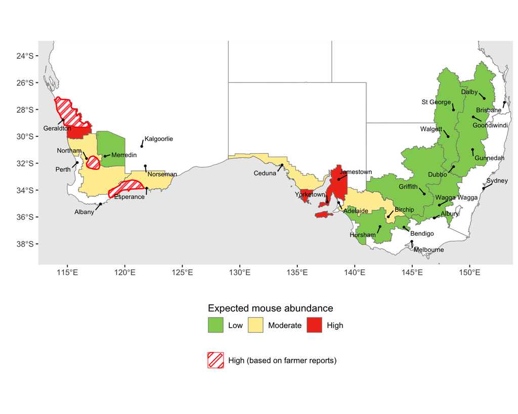

Results of recent mouse monitoring: proportion of sites within each GRDC agro-ecological zone with mice presence (Low = mice detected at 33% of sites or less; Moderate = mice detected between 33 – 67% of sites, High = mice detected at more than 67% of sites). GRDC agro-ecological zones are broad regions of the Australian grain belt defined by similar climate, soils, and farming systems. Monitoring data shows mouse activity to be **high** in SA Midnorth-Lower Yorke Eyre and WA Northern. Monitoring data shows mouse activity to be **moderate** in SA Vic Mallee, WA Central and WA Sandplain.

**Survey regions**

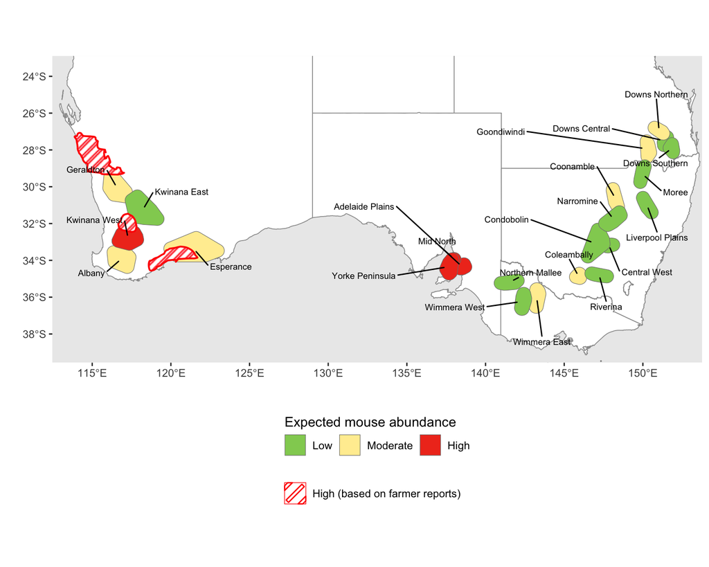

Results of recent mouse monitoring: proportion of sites within each monitoring region with mice presence (Low = mice detected at 33% of sites or less; Moderate = mice detected between 33 – 67% of sites, High = mice detected at more than 67% of sites). Monitoring data shows mouse activity to be **high** in Adelaide Plains, Kwinana West, Mid North and Yorke Peninsula. Monitoring data shows mouse activity to be **moderate** in Albany, Coleambally, Coonamble, Downs Northern, Esperance, Geraldton, Goondiwindi and Wimmera East.

## Management recomendations

1. Monitor mouse activity by walking through paddocks and [searching for active burrows (chew cards could also be used)](https://grdc.com.au/resources-and-publications/resources/mouse-management/monitor-manage/know-your-mouse-numbers). Two or three active burrows per 100 square metres are cause for concern prior to sowing.
2. Where you have identified high mouse activity, [consider applying mouse bait](https://grdc.com.au/resources-and-publications/resources/mouse-management/monitor-manage/mouse-baiting) at seeding to prevent damage to the freshly sown crop. Monitor mouse activity following baiting after application to assess effectiveness of the application. ZnP25 is the only currently registered bait available; use in accordance with the label instructions and report any adverse effects (including a lack of efficacy) via the [APVMA website](https://www.apvma.gov.au/regulation/adverse-experience-reporting-program).
3. Reduce available mouse food (e.g., spilt grain) where possible. High rates of background food directly reduces the effectiveness of poison baiting (as mice are less likely to consume the baits).

## About

Mouse forecasts are enabled through a [Grains Research and Development Corporation and CSIRO investment into the 2025-29 Mouse Monitoring and Surveillance project](https://groundcover.grdc.com.au/grdc/announcements/investments-target-new-normal-of-mouse-activity) via the [Rodent Pest Management team](https://research.csiro.au/rm/). Forecasts will be updated seasonally or as new data comes available.

We are actively developing new statistical models to improve mouse forecasts, and working on their presentation. This work is run in coordination with the National Mouse Group, a grower-led network of farmers, industry representatives, state government, GRDC and CSIRO. The group meet three times a year to update local reports of the current mouse situation, review management recommendations and determine research priorities.

### Monitoring data

Mouse population surveys are conducted 2 - 3 times a year at each of the ~170 long-term monitoring sites. Mice are surveyed through active burrow searches and chewcards. To calibrate this data against more robust population density measurements, we conduct live-trapping at 3 sites (Adelaide Plains SA, Northern Mallee VIC and Central West NSW).

Mouse monitoring data is collected by CSIRO, NSW Local Land Services, NSW Department of Primary Industries and Regional Development, Central West Farming Services, Birchip Cropping Group, & Farmanco. We particularly thank NSW DPIRD who generously provide additional live-trapping survey data. Further live-trapping data is also occasionally supplied through the [GRDC / CSIRO Mouse Ecology 2024-2029 project](https://research.csiro.au/rm/research-projects/mouse-ecology-2024-2029/).

We also receive reports from farmers, agronomists and other community members directly. This is key information we consider given we cannot feasibly survey across the entire grain growing region.

## Report mouse activity

You can quickly report sightings — and importantly, lack of sightings — of mice using our survey form linked below.

We are seeking observations of mice within paddocks (not houses or sheds) from the general public to supplement our scientific survey data. This information will potentially improve our understanding and forecasts of mouse populations.

You will be asked to categorise the level of mouse activity you’ve observed, date and location of the observation, how you observed mice and whether mice were recently baited or not (if known).

Participation is voluntary. We do not think there are any risks involved with taking part in this survey. You may not benefit directly from taking part, but you will be making an important contribution our understanding about mouse populations. Your answers are anonymous and treated as confidential – they will not be publicly released. We will store this data on our secure servers alongside our scientific monitoring data. This survey has been approved by CSIRO’s Social Science Human Research Ethics Committee in accordance with the [National Statement on Ethical Conduct in Human Research (2023)](https://www.csiro.au/en/about/policies/ethical-human-research). If you have questions you can contact the project leader matt.rees@csiro.au or Executive Manager of Social Responsibility and Ethics on +61 7 3833 5693 or csshrec@csiro.au.

If you consent to take part, [access the form to report mouse observations here](https://mouse-forecast.getodk.cloud/f/pSxhfvMR8ElSL70KM52oSPSdeAgbs7x?st=vXkh0bVCMFL8MDb8X0tFALrdFMfq!2CyV3XdJpYz8Y8FsVsyiTpS1pFUYErLYgBP).

## Contact

Questions about the project or forecast? Get in touch with Dr Matthew Rees matt.rees@csiro.au

For media enquiries, contact Research Officer Steve Henry steve.henry@csiro.au or the [CSIRO media office](https://www.csiro.au/en/news/Media-Centre).

We value your feedback.

## 📬 Stay updated

Receive seasonal mouse forecasts to your inbox